# Lista 2

Guilherme Nunes Torma

14 de janeiro de 2022

1. Crie um vetor com os valores $e^{x}\cos{x}$ para os valores de $x=(3,3.1,3.2,...,6)$.

```r
(x <- seq(from = 3, to = 6, by = 0.1))
```

```
##  [1] 3.0 3.1 3.2 3.3 3.4 3.5 3.6 3.7 3.8 3.9 4.0 4.1 4.2 4.3 4.4 4.5 4.6 4.7 4.8
## [20] 4.9 5.0 5.1 5.2 5.3 5.4 5.5 5.6 5.7 5.8 5.9 6.0
```

2. Crie os seguintes vetores.

a)$(0.1^{3}\times 0.2^{1}, 0.1^{6}\times 0.2^{4}, ..., 0.1^{36}\times 0.2^{24})$

O vetor é formado por uma progressão geométrica de formato

$$xa^{0}, xa^{1}, xa^{2}, ..., xa^{n}$$

Onde, x é o primeiro termo e a é a razão.

```r
primeiro_termo <- 0.2^(1) * 0.1e-03
segundo_termo <- 0.2^(4) * 0.1e-06
ultimo_termo <- 0.2^(34) * 0.1e-36
razao <- segundo_termo / primeiro_termo
n <- log(ultimo_termo / primeiro_termo) / log(razao)
sequencia <- c(0, 1:n)
vetor_multiplicador <- razao^sequencia
vetor_a <- primeiro_termo * (vetor_multiplicador)
vetor_a
```

```
##  [1] 2.000000e-05 1.600000e-10 1.280000e-15 1.024000e-20 8.192000e-26
##  [6] 6.553600e-31 5.242880e-36 4.194304e-41 3.355443e-46 2.684355e-51
## [11] 2.147484e-56 1.717987e-61
```

2. $\mathbf{(2,\frac{2^{2}}{2}, \frac{2^{3}}{3}, ..., \frac{2^{25}}{25})}$

```r
sequencia <- seq(1:25)
b <- (2^sequencia) / sequencia
b
```

```
##  [1] 2.000000e+00 2.000000e+00 2.666667e+00 4.000000e+00 6.400000e+00
##  [6] 1.066667e+01 1.828571e+01 3.200000e+01 5.688889e+01 1.024000e+02
## [11] 1.861818e+02 3.413333e+02 6.301538e+02 1.170286e+03 2.184533e+03
## [16] 4.096000e+03 7.710118e+03 1.456356e+04 2.759411e+04 5.242880e+04
## [21] 9.986438e+04 1.906502e+05 3.647221e+05 6.990507e+05 1.342177e+06
```

3. Reproduza a criação do vetor dias da semana (`dds`) mostrado abaixo.

```r
dias <- c("domingo", "segunda", "terça", "quarta", "quinta", "sexta", "sabado")
dds <- seq(1:7)
names(dds) <- dias
dds
```

```
## domingo segunda   terça  quarta  quinta   sexta  sabado
##       1       2       3       4       5       6       7
```

4. Interprete o resultado da seguinte operação

```r
dds_nums <- c(
  5L, 2L, 5L, 2L, 7L, 7L, 2L,
  6L, 6L, 3L, 7L, 1L, 2L, 2L,
  5L, 7L, 3L, 2L, 6L, 4L, 1L
)
names(dds)[dds_nums]
```

```
##  [1] "quinta"  "segunda" "quinta"  "segunda" "sabado"  "sabado"  "segunda"
##  [8] "sexta"   "sexta"   "terça"   "sabado"  "domingo" "segunda" "segunda"
## [15] "quinta"  "sabado"  "terça"   "segunda" "sexta"   "quarta"  "domingo"
```

A operação acima retorna um vetor formado pelos nomes dos elementos do vetor dds alocados de acordo com o índice presente no vetor `dds_num`. Assim, o primeiro termo do novo vetor correponde ao termo de posição 5 (5L) do vetor `dds`, ou seja, quinta e os demais termos são definidos de maneira analoga.

5. 1. Escreva o código necessário para determinar o vetor lógico indicando quais números são pares na sequência de valores 85, 79, 70, 6, 32, 8, 17, 93, 81, 76.

```r
sequencia <- c(85, 79, 70, 6, 32, 8, 17, 93, 81, 76)
pares <- sequencia %% 2 == 0
pares
```

```
##  [1] FALSE FALSE  TRUE  TRUE  TRUE  TRUE FALSE FALSE FALSE  TRUE
```

2. Escreva o total de números ímpares

```r
impares <- !pares
total_impares <- sum(impares)
total_impares
```

```
## [1] 5
```

6. Para um ano ser bissexto, ele deve ser:
- divisível por 4 (a divisão é exata com resto igual a zero)
- não pode ser dívisivel por 100 (a divisão não é exata, ou seja, o resto é diferente de zero)
- pode ser que seja divisível por 400: caso seja divisível por 400, a divisão deve ser exata, deixando o resto igual a zero.

Com os critérios definidos acima, contrua o código para:

1. Verificar se os anos 1894, 1947, 1901, 1992, 1925, 2014, 1993, 1996, 1984, 1897, 2100, 2300 são bissextos.

```r
anos <- c(1894, 1947, 1901, 1992, 1925, 2014, 1993, 1996, 1984, 1897, 2100, 2300)
anos_bissexto <- anos %% 400 == 0 | anos %% 100 != 0 & anos %% 4 == 0
anos_bissexto
```

```
##  [1] FALSE FALSE FALSE  TRUE FALSE FALSE FALSE  TRUE  TRUE FALSE FALSE FALSE
```

b.Mostre quais anos são bissexto

```r
cada_ano_bissexto <- anos * anos_bissexto
cada_ano_bissexto[cada_ano_bissexto > 0]
```

```
## [1] 1992 1996 1984
```

3. Usando o código para verificar se o ano é bissexto, gere um vetor nomeado `ndias` com o número de dias do ano para os anos do item (a).

```r
ndias <- ifelse(
  test = anos_bissexto == TRUE,
  yes = "366 dias",
  no = "365 dias"
)
ndias
```

```
##  [1] "365 dias" "365 dias" "365 dias" "366 dias" "365 dias" "365 dias"
##  [7] "365 dias" "366 dias" "366 dias" "365 dias" "365 dias" "365 dias"
```

4. Programe como obter o total de anos com 366 dias

```r
anos_bissexto <- as.numeric(anos_bissexto)
(total_anos_bissexto <- sum(anos_bissexto))
```

```
## [1] 3
```

7. Quais códigos para gerar os seguintes dados:

```r
seq_a <- c(-30, seq(from = 0, to = 30, by = 5))
seq_a
```

```
## [1] -30   0   5  10  15  20  25  30
```

```r
seq_b <- seq(from = 1.0, to = 0.0, by = -0.2)
seq_b
```

```
## [1] 1.0 0.8 0.6 0.4 0.2 0.0
```

```r
razao <- -2.4434610 - (-3.1415927)
seq_c <- seq(from = -pi, to = pi, by = razao)
seq_c
```

```
##  [1] -3.1415927 -2.4434610 -1.7453293 -1.0471976 -0.3490659  0.3490658
##  [7]  1.0471975  1.7453292  2.4434609  3.1415926
```

```r
repeticao <- 2:8
seq_d <- rep(x = -1:5, times = repeticao)
seq_d
```

```
##  [1] -1 -1  0  0  0  1  1  1  1  2  2  2  2  2  3  3  3  3  3  3  4  4  4  4  4
## [26]  4  4  5  5  5  5  5  5  5  5
```

```r
repeticao <- c(5, 4, 3, 2, 1, 2, 3, 4, 5)
seq_e <- rep(x = repeticao, times = repeticao)
seq_e
```

```
##  [1] 5 5 5 5 5 4 4 4 4 3 3 3 2 2 1 2 2 3 3 3 4 4 4 4 5 5 5 5 5
```

8. Usando o mesmo código para solução em todos os itens abaixo, obtenha as seguintes sequências usando os vetores fornecidos.
1. V3 = (11, 0.25, 7, 2)

```r
v3 <- c(11, 0.25, 7, 2)
v2 <- c(11, 0.25)
v1 <- c(11)
v0 <- c()
vetor <- v3
sequencia <- ifelse(
  test = vetor == 11,
  yes = 1,
  no = vetor
)
sequencia <- ifelse(
  test = vetor == 0.25,
  yes = 2,
  no = sequencia
)
sequencia <- ifelse(
  test = vetor == 7,
  yes = 3,
  no = sequencia
)
sequencia <- ifelse(
  test = vetor == 2,
  yes = 4,
  no = sequencia
)
(sequencia <- as.integer(sequencia))
```

```
## [1] 1 2 3 4
```

2. v2 = (11, 0.25)

```
## [1] 1 2
```

3. V1 = (11)

```
## [1] 1
```

4. V0 = ()

```
## integer(0)
```

9. Considere os seguintes dados horários de temperatura do ar ($\mathbf{T_{ar}}$) registrados em duas estações meteorológicas, entre as 0 e 23 horas de um dado dia.

```r
tar_est1 <- c(
  14.92, 14.61, 14.32, 14.07, 13.84, 13.65, 13.56, 13.97, 15.08,
  16.5, 17.88, 19.08, 20.02, 20.66, 21.01, 21.05, 20.76, 20.05,
  18.77, 17.51, 16.67, 16.11, 15.66, 15.27
)
tar_est2 <- c(
  13.13, 13.01, 12.93, 12.87, 12.82, 12.81, 13.2, 14.22, 15.77,
  17.49, 19.2, 20.57, 21.49, 22.01, 22.03, 21.71, 20.84, 18.77,
  16.54, 15.13, 14.34, 13.81, 13.49, 13.28
)
```

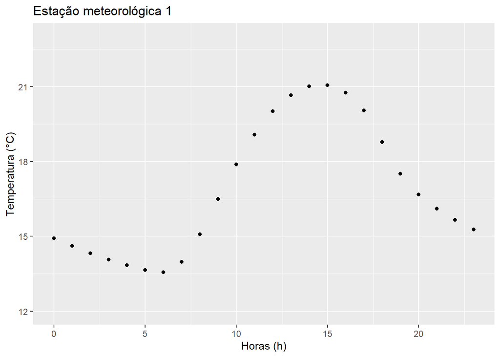

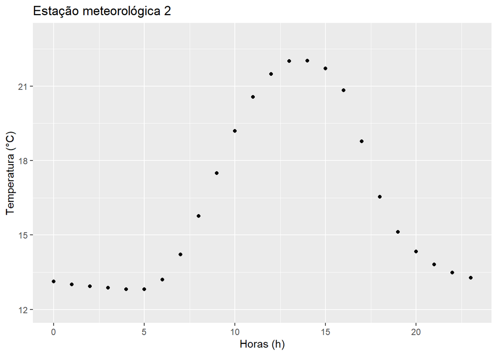

**a.** Determine a média diária $T_{ar}$ das duas estações arredondando para uma casa decimal. Salve a média de cada estação nas variáveis `tmed_est1` e `tmed_est2`.

```r
(tmed_est1 <- round(x = mean(tar_est1), digits = 1))
```

```
## [1] 16.9
```

```r
(tmed_est2 <- round(x = mean(tar_est2), digits = 1))
```

```
## [1] 16.3
```

**b.** Utilizando as variáveis do item anterior, verifique usando comparação lógica, em qual estação o ambiente é mais quente?

```r
ifelse(
  test = tmed_est1 > tmed_est2,
  yes = "Estação 1 é mais quente",
  no = "Estação 2 é mais quente"
)
```

```
## [1] "Estação 1 é mais quente"
```

**c.** Obtenha a 3ª maior temperatura do dia em cada estação.

```r
sort(tar_est1, decreasing = TRUE)[3]
```

```
## [1] 20.76
```

```r
sort(tar_est2, decreasing = TRUE)[3]
```

```
## [1] 21.71
```

**d.** Calcule a amplitude térmica diária ($ATD=T_{max}-T{min}$, onde $T_{max}$: temperatura máxima diária e $T_{min}$: temperatura miníma diária) das estações 1 e 2, arrendondando para uma casa decimal. Salve os resultados nas variaveis `atd_est1` e `atd_est2`.

Amplitude térmica diária estação 1:

```r
tmax_est1 <- max(tar_est1)
tmin_est1 <- min(tar_est1)
(atd_est1 <- round(x = tmax_est1 - tmin_est1, digits = 1))
```

```
## [1] 7.5
```

Amplitude térmica diária estação 2:

```r
tmax_est2 <- max(tar_est2)
tmin_est2 <- min(tar_est2)
(atd_est2 <- round(x = tmax_est2 - tmin_est2, digits = 1))
```

```
## [1] 9.2
```

**e.** Qual o horário de ocorrência das temperaturas máximas e mínimas em cada estação? Salve os resultados nas variáveis `hmax_est{i}` e `hmin_est{i}`, com $i=1,2$

```r
names(tar_est1) <- horas
condicao_max <- tar_est1 == max(tar_est1)
(hmax_est1 <- names(tar_est1[condicao_max]))
```

```
## [1] "15"
```

```r
condicao_min <- tar_est1 == min(tar_est1)
(hmin_est1 <- names(tar_est1[condicao_min]))
```

```
## [1] "6"
```

```
Os horários de ocorrência das temperaturas máxima e mínima da estação 1 são às 15 e às 6 horas respectivamente.
```

```r
names(tar_est2) <- horas
condicao_max <- tar_est2 == max(tar_est2)
(hmax_est2 <- names(tar_est2[condicao_max]))
```

```
## [1] "14"
```

```r
condicao_min <- tar_est2 == min(tar_est2)
(hmin_est2 <- names(tar_est2[condicao_min]))
```

```
## [1] "5"
```

Os horários de ocorrência das temperaturas máxima e mínima da estação 2 são as 14 e 5 horas respectivamente.

**f.** Quando `tar_est2` é maior que `tar_est1` e qual a maior diferença absoluta de temperatura entre as duas estações?

```r
tar_est2_maior <- names(which(tar_est2 > tar_est1))
(tar_est2_inicio <- tar_est2_maior[1])
```

```
## [1] "7"
```

```r
(tar_est2_fim <- tar_est2_maior[length(tar_est2_maior)])
```

```
## [1] "16"
```

A temperatura registrada pela estação 2 é maior das 7 até as 16 horas.

```r
diferenca <- unname(abs(tar_est1 - tar_est2))
(maior_diferenca <- max(diferenca))
```

```
## [1] 2.38
```

A maior diferença absoluta entre as duas estações é de 2.38 °C.

**g.** Qual a hora correspondende a ocorrência daquela maior diferença absoluta de temperatura obtida no item anterior?

```r
names(diferenca) <- horas
diferenca <- (abs(tar_est1 - tar_est2))
maior_diferenca <- max(diferenca)
(hora_maior <- names(which(diferenca == maior_diferenca)))
```

```
## [1] "19"
```

A hora de ocorrência é as 19 horas

**h.** O horário do pôr do sol pode ser estimado a partir da $T_{ar}$. Para o período após o horário de ocorrência da $T_{max}$ determina-se em qual hora ocorre a maior queda de $T_{ar}$ em relação a hora anterior. Estime o horário do pôr do sol para as duas estações ( `hps_est{i}`).

```r
hps_est1 <- names(which(abs(diff(tar_est1)[12:23]) == max(abs(diff(tar_est1)[12:23]))))
hps_est1
```

```
## [1] "18"
```

O horário estimado do pôr do sol para a estação 1 foi às 18 horas.

```r
hps_est2 <- names(which(abs(diff(tar_est2)[12:23]) == max(abs(diff(tar_est2)[12:23]))))
hps_est2
```

```
## [1] "18"
```

O horário estimado do pôr do sol para a estação 2 foi às 18 horas.

**i.** Em quais horas as temperaturas das duas estações estão mais próximas uma da outra, ou seja, com menos de 0,5°C de diferença ?

```r
names(which(diferenca < 0.5))
```

```
## [1] "6"  "7"  "16"
```

As horas em que isso ocorre são às 6, 7 e 16 horas.

**j.** Calcule a temperatura média diária usando os seguintes métodos para estação 2.

$T_{med1} = (T_{max}+T_{min})/2$, salvando em uma variável `tar_met1`

```r
(tar_med1 <- unname((max(tar_est2) + min(tar_est2)) / 2))
```

```
## [1] 17.42
```

$T_{med2} = (T_{max}+T_{min}+T_{9}+2*T_{21})/5$, salvando em uma variável `tar_met2`

```r
(tar_med2 <- unname((max(tar_est2) + min(tar_est2) + tar_est2[10] + 2 * tar_est2[22]) / 5))
```

```
## [1] 15.99
```

$T_{med3} = (T_{7}+T_{14}+2*T_{21})/4$, salvando em uma variável `tar_met3`

```r
(tar_med3 <- unname((tar_est2[8] + tar_est2[15] + 2 * tar_est2[22]) / 4))
```

```
## [1] 15.9675
```

**k.**Compare este resultados com aqueles obtidos no item **a**. Qual é melhor?

```r
tmed_est2
```

```
## [1] 16.3
```

```r
tar_med1
```

```
## [1] 17.42
```

```r
tar_med2
```

```
## [1] 15.99
```

```r
tar_med3
```

```
## [1] 15.9675
```

A `tar_med1` ficou acima da `tmed_est2`, no tempo em que,`tar_med2` e `tar_met3` ficaram abaixo. O valor mais próximo da média aritmética simples foi a `tar_med2` na qual a diferenca foi de 0.31 °C.

10. Calcule a temperatura do ar horária usando o **modelo de onda** para representação do ciclo diário da temperatura do ar, descrito pelas seguintes equações:

$$\left \{\begin{array}{cc}
h_{T_{min}} \leq h < h_{T_{max}},\ T_{calc} = T-A\cos{arg} \\
demais\ horas,\ T_{calc} = T+A\cos{arg} \end{array} \right.$$

onde:
$$T = \left( \frac{T_{max}+T_{min}}{2}\right)$$
e

$$A = \left( \frac{T_{max}-T_{min}}{2}\right)$$
O argumento do cosseno ($arg$) é definido por:

$$\left \{\begin{array}{ccc}
h<h_{T_{min}}, \ arg=\pi\left(\frac{h+10}{10+h_{T_{min}}}\right)\\
h_{T_{min}}\leq h<h_{T_{max}}, \ arg=\pi\left(\frac{h-h_{T_{min}}}{14-h_{T_{min}}} \right)\\
h>h_{T_{min}}, \ arg=\pi\left(\frac{14-h}{10+h_{T_{min}}}\right) \end{array} \right.$$
**a.** Aplique o método acima para estação 1 e 2 substituindo os valores de $T_{max}, T_{min}, h_{T_{min}}$ e $h_{T_{max}}$ adequadamente.

```r
temp_max_est1 <- max(tar_est1)
temp_max_est1
```

```
## [1] 21.05
```

```r
temp_min_est1 <- min(tar_est1)
temp_min_est1
```

```
## [1] 13.56
```

```r
h_temp_min_est1 <- names(which(tar_est1 == temp_min_est1))
h_temp_min_est1
```

```
## [1] "6"
```

```r
h_temp_max_est1 <- names(which(tar_est1 == temp_max_est1))
h_temp_max_est1
```

```
## [1] "15"
```

```r
t_est1 <- (temp_max_est1 + temp_min_est1) / 2
a_est1 <- (temp_max_est1 - temp_min_est1) / 2
```

Para $h<h_{T_{min}}$

```r
tcalc_est1 <- tar_est1
cinco_horas <- as.numeric(h_temp_min_est1) - 1
zero_horas <- as.numeric(names(tcalc_est1[1]))
h_1 <- zero_horas:cinco_horas
arg_1 <- pi * (h_1 + 10) / (10 + as.numeric(h_temp_min_est1))
tcalc_est1[(zero_horas + 1):(cinco_horas + 1)] <- t_est1 + a_est1 * cos(arg_1)
tcalc_est1[(zero_horas + 1):(cinco_horas + 1)]
```

```
##        0        1        2        3        4        5
## 15.87185 15.22439 14.65689 14.19115 13.84507 13.63196
```

Para $h=h_{T_{min}}$

```r
seis_horas <- as.numeric(h_temp_min_est1)
h_2 <- seis_horas
arg_2 <- pi * (h_2 - seis_horas) / (14 - seis_horas)
tcalc_est1[as.numeric(h_temp_min_est1) + 1] <- t_est1 - a_est1 * cos(arg_2)
tcalc_est1[as.numeric(h_temp_min_est1) + 1]
```

```
##     6
## 13.56
```

Para $h_{T_{min}}<h<h_{T_{max}}$

```r
sete_horas <- as.numeric(h_temp_min_est1) + 1
quatorze_horas <- as.numeric(h_temp_max_est1) - 1
h_3 <- sete_horas:quatorze_horas
arg_3 <- pi * (h_3 - as.numeric(h_temp_min_est1)) / (14 - as.numeric(h_temp_min_est1))
tcalc_est1[(sete_horas + 1):(quatorze_horas + 1)] <- t_est1 - a_est1 * cos(arg_3)
tcalc_est1[(sete_horas + 1):(quatorze_horas + 1)]
```

```
##        7        8        9       10       11       12       13       14
## 13.84507 14.65689 15.87185 17.30500 18.73815 19.95311 20.76493 21.05000
```

Para $h \geq h_{T_{max}}$

```r
quinze_horas <- as.numeric(h_temp_max_est1)
ultimo_termo <- length(tcalc_est1)
vinte_tres_horas <- as.numeric(names(tcalc_est1[ultimo_termo]))
h_4 <- quinze_horas:vinte_tres_horas
arg_4 <- pi * (14 - h_4) / (10 + as.numeric(h_temp_min_est1))
tcalc_est1[(quinze_horas + 1):(vinte_tres_horas + 1)] <- t_est1 + a_est1 * cos(arg_4)
tcalc_est1[(quinze_horas + 1):(vinte_tres_horas + 1)]
```

```
##       15       16       17       18       19       20       21       22
## 20.97804 20.76493 20.41885 19.95311 19.38561 18.73815 18.03561 17.30500
##       23
## 16.57439
```

```r
tcalc_est1
```

```
##        0        1        2        3        4        5        6        7
## 15.87185 15.22439 14.65689 14.19115 13.84507 13.63196 13.56000 13.84507
##        8        9       10       11       12       13       14       15
## 14.65689 15.87185 17.30500 18.73815 19.95311 20.76493 21.05000 20.97804
##       16       17       18       19       20       21       22       23
## 20.76493 20.41885 19.95311 19.38561 18.73815 18.03561 17.30500 16.57439
```

```r
temp_max_est2 <- max(tar_est2)
temp_max_est2
```

```
## [1] 22.03
```

```r
temp_min_est2 <- min(tar_est2)
temp_min_est2
```

```
## [1] 12.81
```

```r
h_temp_min_est2 <- names(which(tar_est2 == temp_min_est2))
h_temp_min_est2
```

```
## [1] "5"
```

```r
h_temp_max_est2 <- names(which(tar_est2 == temp_max_est2))
h_temp_max_est2
```

```
## [1] "14"
```

```r
t_est2 <- (temp_max_est2 + temp_min_est2) / 2
a_est2 <- (temp_max_est2 - temp_min_est2) / 2
```

Para $h<h_{T_{min}}$

```r
tcalc_est2 <- tar_est2
quatro_horas <- as.numeric(h_temp_min_est2) - 1
zero_horas <- as.numeric(names(tcalc_est2[1]))
h_1 <- zero_horas:quatro_horas
arg_1 <- pi * (h_1 + 10) / (10 + as.numeric(h_temp_min_est2))
tcalc_est2[(zero_horas + 1):(quatro_horas + 1)] <- t_est2 + a_est2 * cos(arg_1)
tcalc_est2[(zero_horas + 1):(quatro_horas + 1)]
```

```
##        0        1        2        3        4
## 15.11500 14.33531 13.69043 13.20856 12.91074
```

Para $h=h_{T_{min}}$

```r
cinco_horas <- as.numeric(h_temp_min_est2)
h_2 <- cinco_horas
arg_2 <- pi * (h_2 - cinco_horas) / (14 - cinco_horas)
tcalc_est2[as.numeric(h_temp_min_est2) + 1] <- t_est2 - a_est2 * cos(arg_2)
tcalc_est2[as.numeric(h_temp_min_est2) + 1]
```

```
##     5
## 12.81
```

Para $h_{T_{min}}<h<h_{T_{max}}$

```r
seis_horas <- as.numeric(h_temp_min_est2) + 1
treze_horas <- as.numeric(h_temp_max_est2) - 1
h_3 <- seis_horas:treze_horas
arg_3 <- pi * (h_3 - as.numeric(h_temp_min_est2)) / (14 - as.numeric(h_temp_min_est2))
tcalc_est2[(seis_horas + 1):(treze_horas + 1)] <- t_est2 - a_est2 * cos(arg_3)
tcalc_est2[(seis_horas + 1):(treze_horas + 1)]
```

```
##        6        7        8        9       10       11       12       13
## 13.08802 13.88854 15.11500 16.61948 18.22052 19.72500 20.95146 21.75198
```

Para $h \geq h_{T_{max}}$

```r
quatorze_horas <- as.numeric(h_temp_max_est2)
ultimo_termo <- length(tcalc_est2)
vinte_tres_horas <- as.numeric(names(tcalc_est2[ultimo_termo]))
h_4 <- quatorze_horas:vinte_tres_horas
arg_4 <- pi * (14 - h_4) / (10 + as.numeric(h_temp_min_est2))
tcalc_est2[(quatorze_horas + 1):(vinte_tres_horas + 1)] <- t_est2 + a_est2 * cos(arg_4)
tcalc_est2[(quatorze_horas + 1):(vinte_tres_horas + 1)]
```

```
##       14       15       16       17       18       19       20       21
## 22.03000 21.92926 21.63144 21.14957 20.50469 19.72500 18.84457 17.90188
##       22       23
## 16.93812 15.99543
```

```r
tcalc_est2
```

```
##        0        1        2        3        4        5        6        7
## 15.11500 14.33531 13.69043 13.20856 12.91074 12.81000 13.08802 13.88854
##        8        9       10       11       12       13       14       15
## 15.11500 16.61948 18.22052 19.72500 20.95146 21.75198 22.03000 21.92926
##       16       17       18       19       20       21       22       23
## 21.63144 21.14957 20.50469 19.72500 18.84457 17.90188 16.93812 15.99543
```

**b.** Calcule o RMSE nos dois casos.
$$RMSE = \sqrt{\frac{1}{n}\sum_{i=1}^{n}(T_{calc}-T_{abs})^{2}}$$

Primeiro caso

```r
rmse_est1 <- (sum((tcalc_est1 - tar_est1)^2) / length(tcalc_est1))^0.5
rmse_est1
```

```
## [1] 0.9109839
```

Segundo caso

```r
rmse_est2 <- (sum((tcalc_est2 - tar_est2)^2) / length(tcalc_est2))^0.5
rmse_est2
```

```
## [1] 2.133115
```

**c.** Calcule a correlação (r) nos dois casos. A barra representa a média aritmética. Confira seu resultado com a saída da função `cor(tar_obs, tar_calc)`.
$$r = \frac{\sum_{i=1}^{n}(T_{obs}-\bar{T_{obs}})(T_{calc}-\bar{T_{calc}})}{\sqrt(\sum_{i=1}^{n}(T_{obs}-\bar{T_{obs}})^{2}\sum_{i=1}^{n}(T_{calc}-\bar{T_{calc}})^{2})}$$

```r
r_est1 <- sum((tar_est1 - mean(tar_est1)) * (tcalc_est1 - mean(tcalc_est1))) / (sum((tar_est1 - mean(tar_est1))^(2)) * sum((tcalc_est1 - mean(tcalc_est1))^(2)))^0.5
r_est1
```

```
## [1] 0.9534668
```

```r
cor(tar_est1, tcalc_est1)
```

```
## [1] 0.9534668
```

```r
r_est2 <- sum((tar_est2 - mean(tar_est2)) * (tcalc_est2 - mean(tcalc_est2))) / (sum((tar_est2 - mean(tar_est2))^(2)) * sum((tcalc_est2 - mean(tcalc_est2))^(2)))^0.5
r_est2
```

```
## [1] 0.8546298
```

```r
cor(tar_est2, tcalc_est2)
```

```
## [1] 0.8546298
```

Os resultados obtidos através da fórmula e da saída da função foram os mesmos.

11. Os dados abaixo são de precipitação horária de um evento severo ocorrido em 03/12/2012 em Santa Maria-RS.

```r
prec <- rep(0.0, times = 7)
prec <- c(prec, 21.4, 41.2, 2.6, 1.0, 0.4, 0.0)
hora <- seq(from = 9, to = 21, by = 1)
names(prec) <- hora
prec
```

```
##    9   10   11   12   13   14   15   16   17   18   19   20   21
##  0.0  0.0  0.0  0.0  0.0  0.0  0.0 21.4 41.2  2.6  1.0  0.4  0.0
```

```r
tab_1 <- data.frame(
  horas = hora,
  prec = unname(prec)
)
knitr::kable(tab_1)
```

| horas | prec |
| --- | --- |
| 9 | 0.0 |
| 10 | 0.0 |
| 11 | 0.0 |
| 12 | 0.0 |
| 13 | 0.0 |
| 14 | 0.0 |
| 15 | 0.0 |
| 16 | 21.4 |
| 17 | 41.2 |
| 18 | 2.6 |
| 19 | 1.0 |
| 20 | 0.4 |
| 21 | 0.0 |

1. Como seria o código para determinar a soma cumulativa da precipitação horária? Salve o resultado em um vetor chamado `prec_acum`. Interprete o resultado de `c(NA, diff(prec_acum))`.

```r
(prec_acum <- cumsum(prec))
```

```
##    9   10   11   12   13   14   15   16   17   18   19   20   21
##  0.0  0.0  0.0  0.0  0.0  0.0  0.0 21.4 62.6 65.2 66.2 66.6 66.6
```

```r
c(NA, diff(prec_acum))
```

```
##        10   11   12   13   14   15   16   17   18   19   20   21
##   NA  0.0  0.0  0.0  0.0  0.0  0.0 21.4 41.2  2.6  1.0  0.4  0.0
```

A função `diff()` processa a diferença entre o termo e o seu antecessor, de maneira oposta, a função `cumsum` realiza a soma acumulada, ou seja, a soma do termo com o seu sucessor. Dessa forma, ao realizar `diff(prec_acum)` ou, implicitamente, `diff(cumsum(prec))` retorna o vetor `prec` sem o termo inicial que neste caso foi substituido por `NA`.

b.Mostre o código para encontrar o horário de ocorrência da precipitação máxima?

```r
prec_max <- max(prec)
names(which(prec == prec_max))
```

```
## [1] "17"
```

3. Mostre o código para obter a hora de início e fim do evento de precipitação severa. Qual foi a duração do evento?

```r
ocorrencia_prec <- ifelse(
  test = prec == 0,
  yes = NA,
  no = prec
)
ocorrencia_prec <- c(names(ocorrencia_prec[!is.na(ocorrencia_prec)]))
inicio_evento <- ocorrencia_prec[1]
fim_evento <- ocorrencia_prec[length(ocorrencia_prec)]
inicio_evento
```

```
## [1] "16"
```

```r
fim_evento
```

```
## [1] "20"
```

```r
(duracao_prec <- length(ocorrencia_prec))
```

```
## [1] 5
```

O evento de precipitação severa se iniciou as 16 e findou as 20 horas. O evento durou 5 horas.

4. Qual foi a precipitação total do evento? Quanto da precipitação total do evento, em %, ocorreu até às 17 h?

```r
total_prec <- (prec_total <- sum(prec))
```

A precipitação total foi de 66.6.

```r
percentual_17horas <- sum(prec[(1:unname(which(prec == prec["17"])))])
percentual_17horas <- (percentual_17horas / sum(prec)) * 100
percentual_17horas
```

```
## [1] 93.99399
```

Percentual de 93.993994 da precipitação ocorreu até às 17h.

12. Considere o vetor `x` definido pelos números descritos abaixo. Mostre como encontrar o primeiro número positivo localizado após o último número negativo. Por exemplo, seja o vetor z definido pelos valores (11, 10, 15, 2, 6, -15, -10, -22, -8, 5, 7, 2, 12, 8, 4, 1, 3, -3, -1, 30, 14). Os valores selecionados seriam 5 e 30.

```r
x <- c(11, 10, 15, 2, 6, -15, -10, -22, -8, 5, 7, 2, 12, 8, 4, 1, 3, -3, -1, 30, 14)
x_positivo <- ifelse(
  test = x < 0,
  yes = FALSE,
  no = TRUE
)
x_negativo <- which(x_positivo == FALSE)
ultimo_negativo <- x_negativo[length(x_negativo)]
num_positivo <- x[(ultimo_negativo + 1)]
num_positivo
```

```
## [1] 30
```

13. Considerando o vetor `prec` com valores de precipitação diária indicado abaixo. Escreva o código para resolver as seguintes tarefas.

```r
prec <- c(
  0, 0, 0, 0.8, 0, 0.01, 0.75, 0,
  0, 0, 0, 0.35, 0.08, 0, 0, 0, 0, 0.31, 0, 3.57, 12.17, 0, 0,
  0, 0.04, 3.16, 0, 0.95, 0.79, 0, 0, 0, 0, 0, 3.51, 0, 0, 0.16,
  0, 0, 8.16, 0.54, 4.39, 1.24, 0, 0, 0, 0, 0, 2.43, 0, 0, 0, 0,
  0, 7.18, 0, 0, 0.26, 0, 0, 0.28, 0, 0, 0.09, 0.38, 0, 0, 0, 0,
  0, 0, 0.51, 0, 0, 0, 0, 0, 0, 0.67, 0, 0, 0, 0, 0.15, 0, 0.82,
  0, 0, 0, 0, 0, 0, 0, 0, 0.37, 0, 0.58, 4.95, 0, 0, 0, 0, 0, 7.68,
  0, 0, 0.37, 0, 1.56, 0, 0, 0, 0.34, 0.48, 0, 4.21, 2.28, 4.3,
  0, 3.38, 0, 0, 0, 0, 7.28, 0, 4.89, 3.91, 0, 0, 0, 0, 0, 0, 2.93,
  0, 2.49, 0.77, 0, 2.9, 3.53, 0.83, 0, 0, 0, 0.94, 0.59, 0, 0,
  0, 0, 0.04, 0, 0.65, 0, 0, 0, 6.23, 0.09, 0, 0.66, 0, 0, 0, 4.42,
  0, 0, 0, 0.84, 0, 0, 0, 0, 0, 0.09, 0, 0, 0.08, 0, 0.66, 0, 0,
  0, 0.06, 0, 0, 0, 3.28, 0, 0.8, 5.69, 0.8, 0
)
```

1. Quantos dias ocorreram no intervalo 0 < prec < 0.25?

```r
total_dias <- sum(
  ifelse(
    test = prec > 0 & prec < 0.25,
    yes = TRUE,
    no = FALSE
  ))
total_dias
```

```
## [1] 11
```

Total de 11 dias.

2. Substitua os valores de chuva registrados no intervalo 0 < prec < 0.25 por 0.

```r
ifelse(
  test = prec > 0 & prec < 0.25,
  yes = 0,
  no = prec
)
```

```
##   [1]  0.00  0.00  0.00  0.80  0.00  0.00  0.75  0.00  0.00  0.00  0.00  0.35
##  [13]  0.00  0.00  0.00  0.00  0.00  0.31  0.00  3.57 12.17  0.00  0.00  0.00
##  [25]  0.00  3.16  0.00  0.95  0.79  0.00  0.00  0.00  0.00  0.00  3.51  0.00
##  [37]  0.00  0.00  0.00  0.00  8.16  0.54  4.39  1.24  0.00  0.00  0.00  0.00
##  [49]  0.00  2.43  0.00  0.00  0.00  0.00  0.00  7.18  0.00  0.00  0.26  0.00
##  [61]  0.00  0.28  0.00  0.00  0.00  0.38  0.00  0.00  0.00  0.00  0.00  0.00
##  [73]  0.51  0.00  0.00  0.00  0.00  0.00  0.00  0.67  0.00  0.00  0.00  0.00
##  [85]  0.00  0.00  0.82  0.00  0.00  0.00  0.00  0.00  0.00  0.00  0.00  0.37
##  [97]  0.00  0.58  4.95  0.00  0.00  0.00  0.00  0.00  7.68  0.00  0.00  0.37
## [109]  0.00  1.56  0.00  0.00  0.00  0.34  0.48  0.00  4.21  2.28  4.30  0.00
## [121]  3.38  0.00  0.00  0.00  0.00  7.28  0.00  4.89  3.91  0.00  0.00  0.00
## [133]  0.00  0.00  0.00  2.93  0.00  2.49  0.77  0.00  2.90  3.53  0.83  0.00
## [145]  0.00  0.00  0.94  0.59  0.00  0.00  0.00  0.00  0.00  0.00  0.65  0.00
## [157]  0.00  0.00  6.23  0.00  0.00  0.66  0.00  0.00  0.00  4.42  0.00  0.00
## [169]  0.00  0.84  0.00  0.00  0.00  0.00  0.00  0.00  0.00  0.00  0.00  0.00
## [181]  0.66  0.00  0.00  0.00  0.00  0.00  0.00  0.00  3.28  0.00  0.80  5.69
## [193]  0.80  0.00
```

C. Crie um vetor denominado `prec01` indicando o estado da precipitação (chuvoso = 1, seco = 0) baseado no limiar de 0.25 mm para detecção de chuva pelo pluviômetro.

```r
limiar <- 0.25
prec01 <- prec > limiar
prec01 <- as.numeric(prec01)
prec01
```

```
##   [1] 0 0 0 1 0 0 1 0 0 0 0 1 0 0 0 0 0 1 0 1 1 0 0 0 0 1 0 1 1 0 0 0 0 0 1 0 0
##  [38] 0 0 0 1 1 1 1 0 0 0 0 0 1 0 0 0 0 0 1 0 0 1 0 0 1 0 0 0 1 0 0 0 0 0 0 1 0
##  [75] 0 0 0 0 0 1 0 0 0 0 0 0 1 0 0 0 0 0 0 0 0 1 0 1 1 0 0 0 0 0 1 0 0 1 0 1 0
## [112] 0 0 1 1 0 1 1 1 0 1 0 0 0 0 1 0 1 1 0 0 0 0 0 0 1 0 1 1 0 1 1 1 0 0 0 1 1
## [149] 0 0 0 0 0 0 1 0 0 0 1 0 0 1 0 0 0 1 0 0 0 1 0 0 0 0 0 0 0 0 0 0 1 0 0 0 0
## [186] 0 0 0 1 0 1 1 1 0
```

4. Qual a probabilidade de chuva dessa série de precipitação diária?

Probabilidade de 28.3505155.

```r
100 * sum(prec01) / length(prec01)
```

```
## [1] 28.35052
```

5. Qual a probabilidade de chover dois dias consecutivos (`p11`)? Calcule a probabilidade de chover em qualquer um de dois dias consecutivos (`p01` + `p10`)?

```r
deslocado <- lag(prec01)
deslocado <- deslocado[!is.na(deslocado)]
primeiro_termo <- ifelse(
  test = prec01[1] == 1,
  yes = 1,
  no = 0
)
dois_dias <- c(primeiro_termo, deslocado) + prec01
eventos <- length(which(dois_dias == 2))
p11 <- 100 * (eventos / (length(prec01) - 1))
p11
```

```
## [1] 8.290155
```

A probabilidade de chover dois dias é de 8.2901554%.

```r
dois_ou_um <- c(primeiro_termo, deslocado) + prec01
eventos <- length(which(dois_ou_um == 2 | dois_ou_um == 1))
p10 <- 100 * (eventos / (length(prec01) - 1))
p10
```

```
## [1] 48.70466
```

A probabilidade de chover em qualquer um de dois dias consecutivos é de 48.7046632%.

6. Determine a duração de cada evento chuvoso (número de dias consecutivos).

```r
deslocado_ini <- lag(prec01)
deslocado_ini <- deslocado_ini[!is.na(deslocado_ini)]
primeiro_termo <- ifelse(
  test = prec01[1] == 1,
  yes = 1,
  no = 0
)
eventos01_ini <- c(primeiro_termo, deslocado_ini) - prec01
(eventos01_ini <- (which(eventos01_ini < 0)))
```

```
##  [1]   4   7  12  18  20  26  28  35  41  50  56  59  62  66  73  80  87  96  98
## [20] 105 108 110 114 117 121 126 128 136 138 141 147 155 159 162 166 170 181 189
## [39] 191
```

```r
deslocado_fim <- lead(prec01)
deslocado_fim <- deslocado_fim[!is.na(deslocado_fim)]
ultimo_termo <- ifelse(
  test = prec01[length(prec01)] == 1,
  yes = 1,
  no = 0
)
eventos01_fim <- c(deslocado_fim, ultimo_termo) - prec01
(eventos01_fim <- which(eventos01_fim < 0))
```

```
##  [1]   4   7  12  18  21  26  29  35  44  50  56  59  62  66  73  80  87  96  99
## [20] 105 108 110 115 119 121 126 129 136 139 143 148 155 159 162 166 170 181 189
## [39] 193
```

```r
(duracao <- eventos01_fim - eventos01_ini + 1)
```

```
##  [1] 1 1 1 1 2 1 2 1 4 1 1 1 1 1 1 1 1 1 2 1 1 1 2 3 1 1 2 1 2 3 2 1 1 1 1 1 1 1
## [39] 3
```

```r
duracao2 <- c(
  evento1 = 1, evento2 = 1, evento3 = 1, evento4 = 1, evento5 = 2,
  evento6 = 1, evento7 = 2, evento8 = 1, evento9 = 4, evento10 = 1,
  evento11 = 1, evento12 = 1, evento13 = 1, evento14 = 1, evento15 = 1,
  evento16 = 1, evento17 = 1, evento18 = 1, evento19 = 2, evento20 = 1,
  evento21 = 1, evento22 = 1, evento23 = 2, evento24 = 3, evento25 = 1,
  evento26 = 1, evento27 = 2, evento28 = 1, evento29 = 2, evento30 = 3,
  evento31 = 2, evento32 = 1, evento33 = 1, evento34 = 1, evento35 = 1,
  evento36 = 1, evento37 = 1, evento38 = 1, evento39 = 3
)
nome_eventos <- names(duracao2)
names(duracao) <- nome_eventos
duracao
```

```
##  evento1  evento2  evento3  evento4  evento5  evento6  evento7  evento8
##        1        1        1        1        2        1        2        1
##  evento9 evento10 evento11 evento12 evento13 evento14 evento15 evento16
##        4        1        1        1        1        1        1        1
## evento17 evento18 evento19 evento20 evento21 evento22 evento23 evento24
##        1        1        2        1        1        1        2        3
## evento25 evento26 evento27 evento28 evento29 evento30 evento31 evento32
##        1        1        2        1        2        3        2        1
## evento33 evento34 evento35 evento36 evento37 evento38 evento39
##        1        1        1        1        1        1        3
```

14. Dado o vetor `dados` mostrado abaixo.

```r
dados <- c(
  NA, NA, 27L, 7L, 4L, 0L, 26L, 15L, 25L, NA, NA, NA, NA, 6L,
  29L, 18L, 17L, 23L, 20L, 1L, 30L, 13L, NA, NA, NA, NA, NA, NA,
  NA, 19L
)
```

a.Como você pode codificar a obtenção de um vetor com zeros nos valores válidos e com números sequenciais dentro das falhas?

```r
dados_a <- ifelse(
  test = !is.na(dados) == TRUE,
  yes = 0,
  no = seq(1:length(dados))
)
dados_a
```

```
##  [1]  1  2  0  0  0  0  0  0  0 10 11 12 13  0  0  0  0  0  0  0  0  0 23 24 25
## [26] 26 27 28 29  0
```

2. Como a partir do vetor resultante do item anterior você pode obter um vetor cujo os valores dentro das falhas indique a ordem de ocorrência da falha.

```
##  [1]  1  2 10 11 12 13 23 24 25 26 27 28 29
```

```
##  [1]  1  2  3  4  5  6  7  8  9 10 11 12 13
```

```
##  [1]  1  2  0  0  0  0  0  0  0 10 11 12 13  0  0  0  0  0  0  0  0  0 23 24 25
## [26] 26 27 28 29  0
```

```
##  [1]  1  8  1  1  1 10  1  1  1  1  1  1  1
```

3. Qual o código para determinar o tamanho de cada falha?

```r
dados_b01 <- ifelse(
  test = dados_a != 0,
  yes = 1,
  no = 0
)
deslocado_ini <- lag(dados_b01)
deslocado_ini <- deslocado_ini[!is.na(deslocado_ini)]
primeiro_termo <- ifelse(
  test = dados_b01[1] == 1,
  yes = 1,
  no = 0
)
eventos01_ini <- c(primeiro_termo, deslocado_ini) - dados_b01
eventos01_ini <- c(primeiro_termo, which(eventos01_ini < 0))


deslocado_fim <- lead(dados_b01)
deslocado_fim <- deslocado_fim[!is.na(deslocado_fim)]
ultimo_termo <- ifelse(
  test = dados_b01[length(dados_b01)] == 1,
  yes = 1,
  no = 0
)
eventos01_fim <- c(deslocado_fim, ultimo_termo) - dados_b01
eventos01_fim <- c(which(eventos01_fim < 0))
(duracao <- eventos01_fim - eventos01_ini + 1)
```

```
## [1] 2 4 7
```

4. Como determinar o tamanho da maior falha?

```r
max(duracao)
```

```
## [1] 7
```

15. Para os valores de velocidade ($V_{h}$) e a direção do vento ($\theta$) (na convenção meteorológica):

$V_{h}$ = (10, 10, 10, 10, 14.142, 14.142, 14.142, 14.142, 0)

$\theta$ = (270, 180, 360, 90, 225, 315, 135, 45, 0)

1. Determine as componentes e do vento.

$$u= -V_{h} \cdot \sin{\theta_{rad}}$$
$$u= -V_{h} \cdot \cos{\theta_{rad}}$$

```r
theta <- c(270, 180, 360, 90, 225, 315, 135, 45, 0)
velocidade <- c(10, 10, 10, 10, 14.142, 14.142, 14.142, 14.142, 0)
velocidade <- (velocidade >= 0.5) * velocidade
theta_rad <- theta * (pi / 180)
u <- -velocidade * sin(theta_rad)
round(u, digits = 2)
```

```
## [1]  10   0   0 -10  10  10 -10 -10   0
```

```r
v <- -velocidade * cos(theta_rad)
round(v, digits = 2)
```

```
## [1]   0  10 -10   0  10 -10  10 -10   0
```

2. Faça os cálculos necessários para reconstruir $V_{h}$ e $\theta$, a partir de u e v determinado no item **a**. Por convenção, a direção do vento $\theta$ em condições calmas ($V_{h} < 0.5 m s^{-1}$) é assumida como 0°.

$$V_{h} = \sqrt{(u^{2}+v^{2})}$$

```r
(ws <- sqrt(u^2+v^2))
```

```
## [1] 10.000 10.000 10.000 10.000 14.142 14.142 14.142 14.142  0.000
```

$$\theta_{mat} = atan2 (-u, -v)\cdot \frac{180}{\pi}$$
$$\theta = \left \{ \begin{array}{cc}
\theta_{mat} + 360 \ se \ \theta_{mat} < 0 \\
0 \ se \ u= 0, v=0 \ ou \ V_{h} < 0.5 \end{array} \right.$$
A tabela abaixo apresenta o resultado esperado para as variáveis derivadas.

```r
theta_mat <- atan2(-u, -v) * (180 / pi)
wd_uv <- ifelse(
  test = theta_mat < 0,
  yes = theta_mat + 360,
  no = theta_mat
)
wd_uv
```

```
## [1] 270 180 360  90 225 315 135  45   0
```

A tabela abaixo apresenta o resultado esperado para as variáveis derivadas.

Dica: ver figura abaixo.

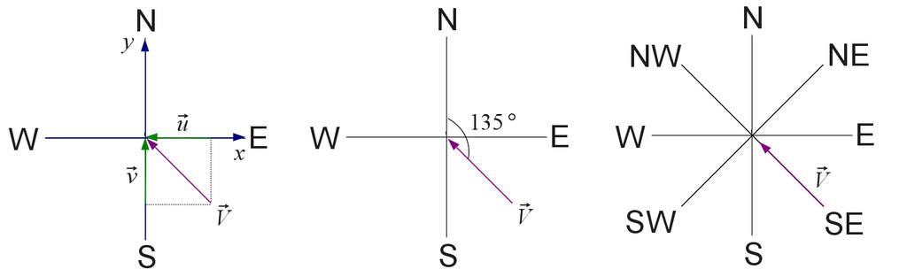

```r
dir <- c("Oeste", "Sul", "Norte", "Leste", "Sudoeste", "Noroeste", "Sudeste", "Nordeste", "Calmo")
wds <- setNames(
  object = wd_uv,
  nm = dir
)
```

```r
tab_2 <- data.frame(
  u = round(x = u, digits = 0),
  v = round(x = v, digits = 0),
  ws = ws,
  wd = theta,
  wd_uv = wd_uv,
  dir = dir
)
knitr::kable(tab_2)
```

| u | v | ws | wd | wd_uv | dir |
| --- | --- | --- | --- | --- | --- |
| 10 | 0 | 10.000 | 270 | 270 | Oeste |
| 0 | 10 | 10.000 | 180 | 180 | Sul |
| 0 | -10 | 10.000 | 360 | 360 | Norte |
| -10 | 0 | 10.000 | 90 | 90 | Leste |
| 10 | 10 | 14.142 | 225 | 225 | Sudoeste |
| 10 | -10 | 14.142 | 315 | 315 | Noroeste |
| -10 | 10 | 14.142 | 135 | 135 | Sudeste |
| -10 | -10 | 14.142 | 45 | 45 | Nordeste |
| 0 | 0 | 0.000 | 0 | 0 | Calmo |

16. Para as séries de `prec_obs` e `prec_sim` calcule:
1. A proporção corretamente prevista $PC = \frac{wc+dc}{n}$
2. O índice de sucesso crítico $CSI = \frac{wc}{wc+wi+di}$

Onde $wc$ e $dc$ são as previsões corretas de dias úmidos ($prec>0,25\ mm\ dia^{-1}$) e secos respectivamente, $wi$ e $di$ são as previsões incorretas de dias úmidos e secos respectivamente $n$ é o n° total de previsões.

```r
prec_obs <- c(
  0, 0, 0, 0.5, 1, 6, 9, 0.2, 1, 0, 0, 0.25,
  10, 15, 8, 3, 0, 0, 0, 0, 0, 0, 0.25, 0,
  0, 0, 1, 5, 0, 20, 0, 0, 0, 0, 1, 1,
  0, 2, 12, 1, 0, 0, 0, 0, 0, 0, 5, 5
)
prec_sim <- c(
  0, 0.2, 0.1, 0, 0, 3, 1, 1, 1, 1, 0, 3,
  0, 10, 4, 1, 0.3, 0.5, 0.5, 0.5, 0.5, 0, 0.25, 0.25,
  0.25, 0, 0.5, 3, 0, 5, 0, 0, 0, 0, 0.5, 0,
  0.25, 0.2, 0, 0.2, 0, 0, 0, 0, 1, 2, 1, 0
)
```

```r
wc_obs <- (prec_obs > 0.25)
wc_sim <- (prec_sim > 0.25)
wc <- length(which(wc_obs == wc_sim & wc_obs == TRUE))
dc <- length(which(wc_obs == wc_sim & wc_obs == FALSE))
pc <- (wc + dc) / length(prec_obs)
pc
```

```
## [1] 0.625
```

```r
wi <- length(which(wc_obs != wc_sim & wc_obs == TRUE))
di <- length(which(wc_obs != wc_sim & wc_obs == FALSE))
csi <- wc / (wc + wi + di)
csi
```

```
## [1] 0.3793103
```

A proporção corretamente prevista é de 0.625; o índice de sucesso crítico, de 0.3793103.

17. Escreva o código para calcular as estatísticas abaixo, entre os vetores de valores observados (`obs`) e previstos (`prev`) por um dado modelo atmosférico, em um dado local.
1. O Viés relativo (%)
   $$PBIAS = 100 \frac{\sum_{i=1}^{n}(Prev_{i}-Obs_{i})}{\sum_{i=1}^{n}(Obs_{i})}$$
2. Coeficente de eficiência de Nash-Sutcliffe (NSE).
   $$NSE = 1- \frac{\sum_{i=1}^{n}(Obs_{i}-Prev_{i})^{2}}{\sum_{i=1}^{n}(Obs_{i}-\bar{Obs_{i}})^{2}}$$

```r
v_obs <- c(
  -0.49, 0.27, -0.48, 0.8, -1, 0.1, -1.16,
  0.58, -1.6, -0.31, 0.45, -0.98, 0.19, 0.73,
  -0.49, -0.04, -0.11, 0.46, 2.02, -1.05
)
v_prev <- c(
  NA, -0.49, 0.27, -0.48, 0.8, -1, 0.1, -1.16,
  0.58, -1.6, -0.31, 0.45, -0.98, 0.19, 0.73,
  -0.49, -0.04, -0.11, 0.46, 2.02
)

v_obs <- v_obs[which(!is.na(v_prev))]
v_prev2 <- v_prev[!is.na(v_prev)]
pbias <- 100 * (sum(v_prev2 - v_obs)) / (sum(v_obs))
pbias
```

```
## [1] -34.5679
```

```r
nse <- 1 - (sum((v_obs - v_prev2)^{
  2
})) / (sum((v_obs - mean(v_obs))^{
  2
}))
nse
```

```
## [1] -1.691282
```

O viés relativo é igual a -34.5679012, o coeficiente de eficiência de Nash-Sutcliff igual a -1.6912824.